# Arkansas River - Random Forest Testing on GDE Plant Functional Groups

Matthew Lurtz

2025-10-24

## Science Question

The main goal in this manuscript is to test if a given plant functional group (e.g., response variable, NDVI derived from Planet Imagery) has a stronger correlation or dependence with a specific hydroclimatic variable (e.g., covariate, groundwater depth or rainfall, or temperature, etc.). Notably, we will also test if this dependence changes with respect to the temporal resolution (i.e., daily, weekly, and monthly) at which we regress the covariates on the response variable and how the depedence changes during wet and dry years.

## Methodology

The approach is multifaceted:

1. Straight forward application of Random Forest to deduce the most predictive covariates in NDVI and see if they differ based on plant functional group (PFG) using a daily temporal resolution. *All the major PFGs* will be compared to the NDVI response of *fallow land*. This approach will be carried out using the entire *population of data* and then repeated after separating the response variable and covariates into *wet and dry years*.
2. Straight forward application of Random Forest to deduce the most predictive covariates in NDVI and see if they differ based on plant functional group (PFG) using *weekly and monthly temporal resolutions*. This will make for a direct comparison to approach no. 1.
3. In order to detrend and-or deseasonalize the response variable, Singular Spectrum Analysis is applied to the response variable to decompose the time series from the annual periodicity.

## Bring in Y and X Datasets (Daily)

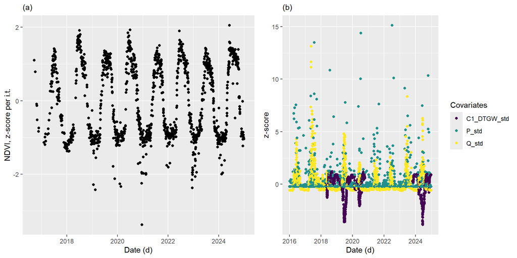

Figure 1. Daily observations of the response variable and select covariates: (a) standardized NDVI, and (b) averages or summations of precipitation, discharge, and depth to groundwater all plotted on a standarized scale.

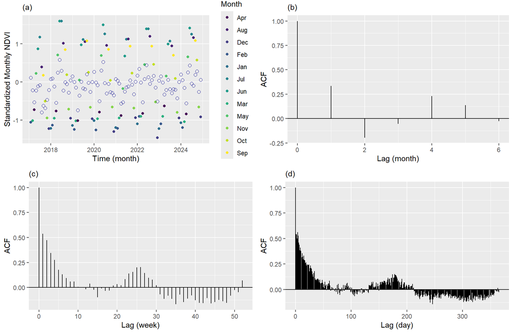

## Data and Methods

Table. A tabular list of covariates tested in the Random Forest algorithm using the Ranger package. All covariates are standardized at the daily temporal resolution.

Covariate

Form

Source

Lagged

Groundwater Depth (m)

15min Avg. To Daily

Well C1

Day, Weekly Avg., Monthly Avg.

Groundwater Temp. (Cels.)

15min Avg. To Daily

Well C1

Day, Weekly Avg., Monthly Avg.

Discharge (cms)

Daily Avg.

ARKROCCO

Day, Weekly Avg., Monthly Avg.

Gage Height (m)

Daily Avg.

ARKROCCO

Day, Weekly Avg., Monthly Avg.

Surf. Water Temp. (Cels.)

Daily Avg.

ARKROCCO

Day, Weekly Avg., Monthly Avg.

Avg. Atmos. Temp. (Cels.)

Daily Avg.

RFD01

Day, Weekly Avg., Monthly Avg.

RH (percent)

Daily Avg.

RFD01

Day, Weekly Avg., Monthly Avg.

Vapor Press. (kPa)

Daily Avg.

RFD01

Day, Weekly Avg., Monthly Avg.

Precip. (mm)

Daily Sum

RFD01

Day, Weekly Avg., Monthly Avg.

Wind Run (km)

Daily Avg.

RFD01

Day, Weekly Avg., Monthly Avg.

Gust Speed (m.s)

Daily Avg.

RFD01

Day, Weekly Avg., Monthly Avg.

Solar Rad. (W.m.2)

Daily Avg.

RFD01

Day, Weekly Avg., Monthly Avg.

ASCE ETr (mm)

Daily Avg.

RFD01

Day, Weekly Avg., Monthly Avg.

NDVI

Rep. and Obs. Daily Avg.

Planet

Day, Weekly Avg., Monthly Avg.

Atmos. Temp. and GW Temp. Diff.

Daily Avg.

Well C1 and RFD01

Day, Weekly Avg., Monthly Avg.

3-mo Lag

Table. Latitude and longitude location for the 12 groundwater wells located near Rocky Ford, Colorado.

| Well_ID | Lon | Lat |
| --- | --- | --- |
| A1 | -103.6872 | 38.05882 |
| A2 | -103.6851 | 38.05830 |
| A3 | -103.6858 | 38.05564 |
| A4 | -103.6846 | 38.05482 |
| B1 | -103.6834 | 38.04795 |
| B2 | -103.6835 | 38.04926 |
| B3 | -103.6830 | 38.05027 |
| B4 | -103.6830 | 38.05200 |
| C1 | -103.6749 | 38.05061 |
| C2 | -103.6725 | 38.05224 |
| C3 | -103.6720 | 38.05291 |
| C4 | -103.6711 | 38.05374 |

## Wet and Dry Years, Defined

1. Use differences in discharge.
2. Use differences in rainfall.
3. Use differences in reservoir release.
4. Use differences, from prior years, of snowpack in upper Arkansas watershed.

## Random Forest (Monthly, All PFGs)

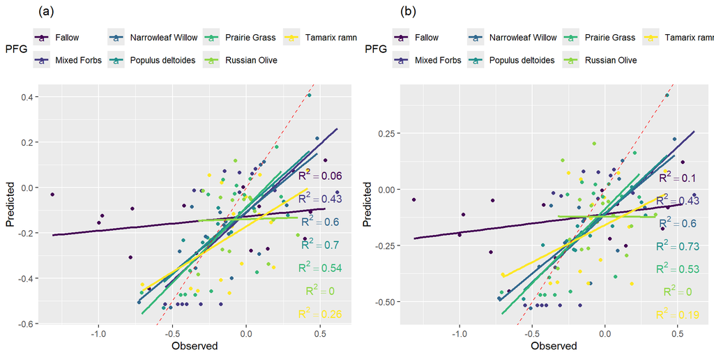

Figure 3. OOS model validation, using 20 percent of original dataset, for all PFGs at a monthly time resolution with a 1:1 (red-dashed) line plot and a regression (color by PFG) line to highlight predictive accuracy and bias of the witheld (i.e., testing) dataset: a) all covariates tested and b) top ten covariates tested from the first iteration.

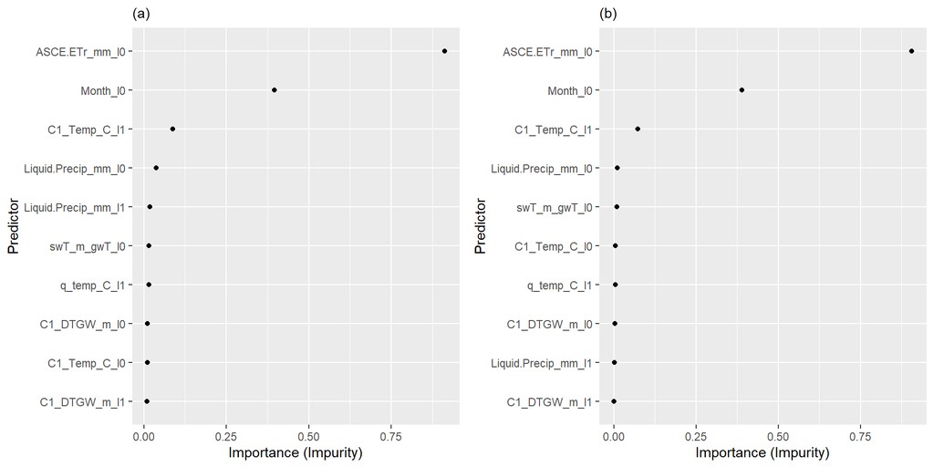

Figure 4. Top 10 variables plotted in terms of feature importance based on impurity: a) all covariates tested and b) top ten covariates tested from the first iteration. This Impurity is based on the average total reduction of the loss function for a given feature across all trees. Reference: (https://bradleyboehmke.github.io/HOML/random-forest.html).

## Random Forest (Weekly, All PFGs)

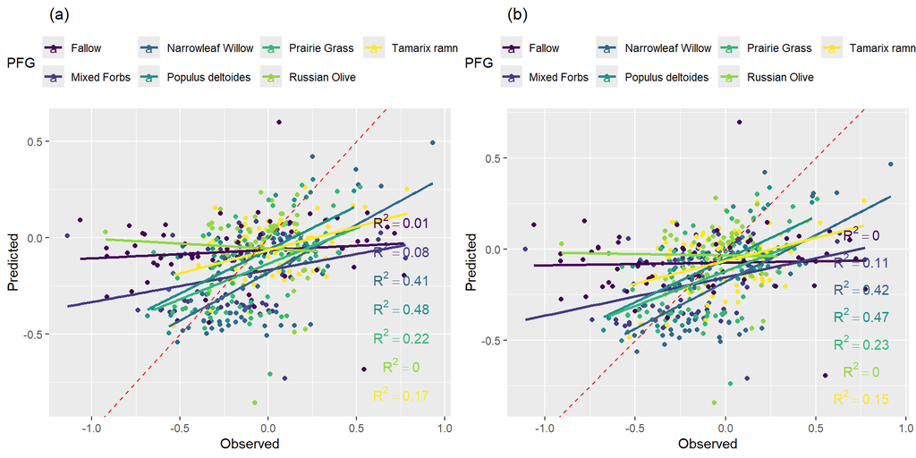

Figure 5. OOS model validation, using 20 percent of original dataset, for all PFGs at a weekly time resolution with a 1:1 (red-dashed) line plot and a regression (color by PFG) line to highlight predictive accuracy and bias of the witheld (i.e., testing) dataset: a) all covariates tested using deseasonalized-filtered data and b) all covariates tested using the kalman-filtered data.

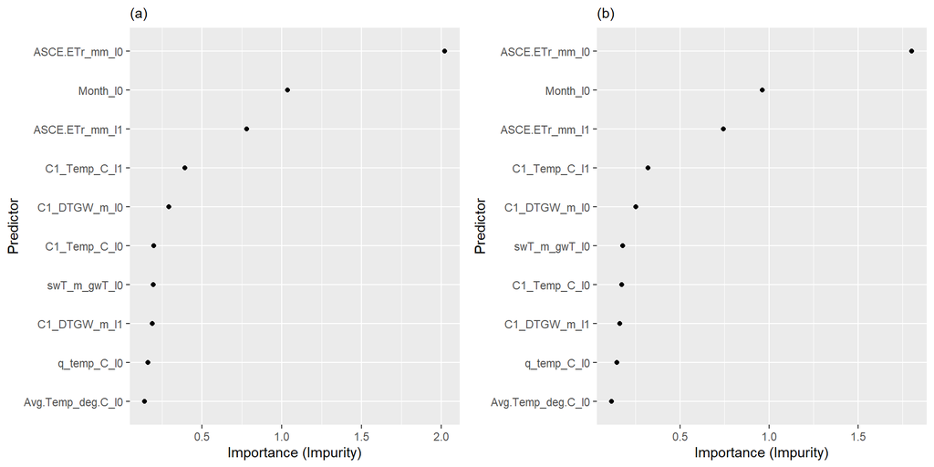

Figure 6. Top 10 variables plotted in terms of feature importance based on impurity: a) all covariates tested using deseasonalized-filtered data and b) all covariates tested using the kalman-filtered data. Impurity is based on the average total reduction of the loss function for a given feature across all trees. Reference: (https://bradleyboehmke.github.io/HOML/random-forest.html).

## Random Forest (Daily, All PFGs)

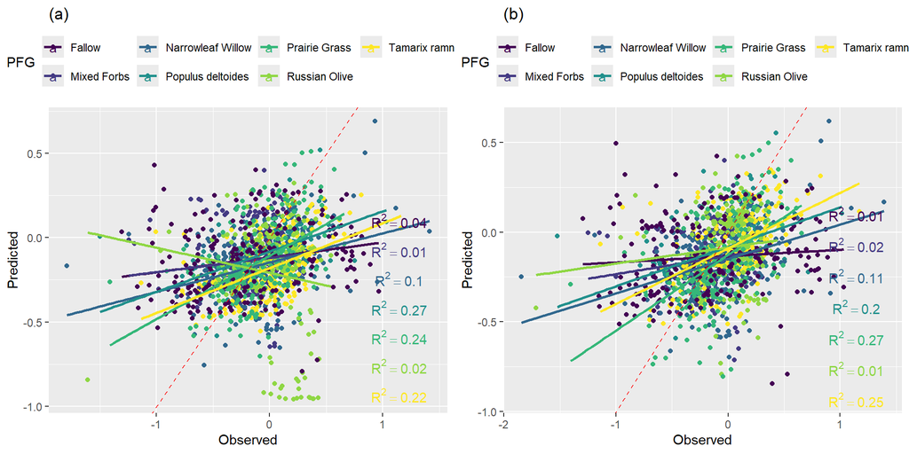

Figure 7. OOS model validation, using 20 percent of original dataset, for all PFGs at a daily time resolution with a 1:1 (red-dashed) line plot and a regression (color by PFG) line to highlight predictive accuracy and bias of the witheld (i.e., testing) dataset: a) all covariates tested using deseasonalized-filtered data and b) all covariates tested using the kalman-filtered data.

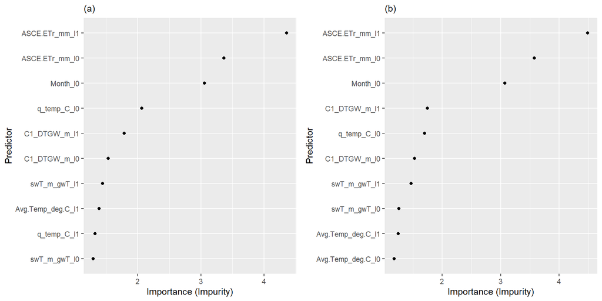

Figure 8. Top 10 variables plotted in terms of feature importance based on impurity: a) all covariates tested using deseasonalized-filtered data and b) all covariates tested using the kalman-filtered data. Impurity is based on the average total reduction of the loss function for a given feature across all trees. Reference: (https://bradleyboehmke.github.io/HOML/random-forest.html).